# Analyzing marginal effects for recommendations of ffacoach

The following notebook analyzes the degree to which the recommended, actionable suggestions to improved wellbeing are issued and how they are distributed. The main purpose is to validate that the model is sensitive to individual characteristics issuing recommendations across the different drivers and not simply bluntly recommending to eat more vegetables.

```python
import sys
import os
import pandas as pd
import matplotlib
import matplotlib.pyplot as plt
import numpy as np
import plotly.graph_objects as go

np.random.seed(42)

sys.path
sys.path.append('/data/rest/ffacoach')

from FFA.Coach import Coach
```

```
Connecting to H2O server at http://localhost:54321 ... successful.
```

| H2O cluster uptime: | 1 day 10 hours 26 mins |
| --- | --- |
| H2O cluster timezone: | Europe/Berlin |
| H2O data parsing timezone: | UTC |
| H2O cluster version: | 3.28.0.2 |
| H2O cluster version age: | 3 months and 14 days !!! |
| H2O cluster name: | uli |
| H2O cluster total nodes: | 1 |
| H2O cluster free memory: | 13.39 Gb |
| H2O cluster total cores: | 24 |
| H2O cluster allowed cores: | 20 |
| H2O cluster status: | locked, healthy |
| H2O connection url: | http://localhost:54321 |
| H2O connection proxy: | {'http': None, 'https': None} |
| H2O internal security: | False |
| H2O API Extensions: | Amazon S3, XGBoost, Algos, AutoML, Core V3, TargetEncoder, Core V4 |
| Python version: | 3.7.3 final |

```python
os.environ["COACH_MODEL"] = "/data/models/rf_wellbeing_classification"
ffaCoach = Coach()

meta = ffaCoach.get_meta()
meta

all_meta = []

for m in meta:
    all_meta.append({
        "_changed" : m["varname"],
        "q_en" : m['q_en']
    })

df_meta = pd.DataFrame(all_meta)
```

```python
# Load the data as numeric values
df_wellbeing = pd.read_csv("/data/data/df_base_numeric.csv")
```

### Creating the simulated vectors on the entire dataset

The class of ffacoach also contains function to modify the simulated improvements and returns a list of modified feature vectors. This is the input for further analysis

```python
all_simulated = []
all_input_v = []
for index, row in df_wellbeing.iterrows():
    r = row.to_dict()
    input_vector, simulated_vectors = ffaCoach.simulate_input_vectors(r)

    # simulated_vectors.append(input_vector)

    all_simulated += simulated_vectors
    all_input_v.append(input_vector)
len(all_simulated)
```

```
202744
```

```python
df_actuals_predicted = ffaCoach.estimate_wellbeing(all_input_v)
df_simulated_predicted = ffaCoach.estimate_wellbeing(all_simulated)
```

```
list
Parse progress: |█████████████████████████████████████████████████████████| 100%
drf prediction progress: |████████████████████████████████████████████████| 100%
list
Parse progress: |█████████████████████████████████████████████████████████| 100%
drf prediction progress: |████████████████████████████████████████████████| 100%
```

```python
df_actuals = pd.DataFrame(all_input_v)
df_actuals = pd.concat([df_actuals.reset_index(drop=True), df_actuals_predicted], axis=1)

df_actuals.head(5)
```

|  | sex | age5B | MIbirthplace | MIcitizen | bula | PAgroe | PAgewiB | IAkv1D | SDaeqeink_k | SDbild4C | ... | GZmehm1 | _id | _id_parent | new | predict | p1 | p2 | p3 | p4 | p5 |
| --- | --- | --- | --- | --- | --- | --- | --- | --- | --- | --- | --- | --- | --- | --- | --- | --- | --- | --- | --- | --- | --- |
| 0 | 2.0 | 4.0 | 10.0 | 10.0 | 1.0 | 167.0 | 52.0 | 2.0 | 6.0 | 5.0 | ... | 4.0 | df_a58e23d0-8eb2-11ea-914e-7d44e9ec5279 | None | 0 | 4 | 0.0 | 0.0 | 0.162409 | 0.802897 | 0.034693 |
| 1 | 2.0 | 8.0 | 10.0 | 10.0 | 8.0 | 162.0 | 55.0 | 1.0 | 6.0 | 4.0 | ... | 4.0 | df_a58e23e7-8eb2-11ea-914e-7d44e9ec5279 | None | 0 | 4 | 0.0 | 0.0 | 0.000104 | 0.604921 | 0.394975 |
| 2 | 2.0 | 8.0 | 10.0 | 10.0 | 3.0 | 161.0 | 87.0 | 1.0 | 5.0 | 2.0 | ... | 3.0 | df_a58e23fe-8eb2-11ea-914e-7d44e9ec5279 | None | 0 | 3 | 0.0 | 0.0 | 0.929029 | 0.070971 | 0.000000 |
| 3 | 2.0 | 7.0 | 22.0 | 10.0 | 10.0 | 164.0 | 63.0 | 1.0 | 2.0 | 16.0 | ... | 4.0 | df_a58e2415-8eb2-11ea-914e-7d44e9ec5279 | None | 0 | 4 | 0.0 | 0.0 | 0.213302 | 0.677000 | 0.109698 |
| 4 | 2.0 | 10.0 | 10.0 | 10.0 | 5.0 | 168.0 | 69.0 | 1.0 | 4.0 | 3.0 | ... | 5.0 | df_a58e242c-8eb2-11ea-914e-7d44e9ec5279 | None | 0 | 5 | 0.0 | 0.0 | 0.206897 | 0.172414 | 0.620690 |

5 rows × 102 columns

```python
df_actuals.rename({
    "predict" : "orig_predict",
    "p1" : "orig_p1",
    "p2" : "orig_p2",
    "p3" : "orig_p3",
    "p4" : "orig_p4",
    "p5" : "orig_p5",
    }, inplace=True, axis=1)
```

```python
def get_score(row):
    return row["orig_p" + str(row["orig_predict"])]

df_actuals["orig_class_score"] = df_actuals.apply(lambda x: get_score(x), axis=1)
df_actuals_selected = df_actuals[["_id", "orig_predict", "orig_p1", "orig_p2", "orig_p3", "orig_p4", "orig_p5", "orig_class_score"]]

df_actuals_selected.rename({
    "_id" : "_id_parent"
    }, inplace=True, axis=1)

df_actuals_selected.head(5)
```

|  | _id_parent | orig_predict | orig_p1 | orig_p2 | orig_p3 | orig_p4 | orig_p5 | orig_class_score |
| --- | --- | --- | --- | --- | --- | --- | --- | --- |
| 0 | df_a58e23d0-8eb2-11ea-914e-7d44e9ec5279 | 4 | 0.0 | 0.0 | 0.162409 | 0.802897 | 0.034693 | 0.802897 |
| 1 | df_a58e23e7-8eb2-11ea-914e-7d44e9ec5279 | 4 | 0.0 | 0.0 | 0.000104 | 0.604921 | 0.394975 | 0.604921 |
| 2 | df_a58e23fe-8eb2-11ea-914e-7d44e9ec5279 | 3 | 0.0 | 0.0 | 0.929029 | 0.070971 | 0.000000 | 0.929029 |
| 3 | df_a58e2415-8eb2-11ea-914e-7d44e9ec5279 | 4 | 0.0 | 0.0 | 0.213302 | 0.677000 | 0.109698 | 0.677000 |
| 4 | df_a58e242c-8eb2-11ea-914e-7d44e9ec5279 | 5 | 0.0 | 0.0 | 0.206897 | 0.172414 | 0.620690 | 0.620690 |

```python
df_simulated_vectors = pd.DataFrame(all_simulated)
df_simulated_vectors = pd.concat([df_simulated_vectors.reset_index(drop=True), df_simulated_predicted], axis=1)
df_simulated_vectors.head(5)
```

|  | sex | age5B | MIbirthplace | MIcitizen | bula | PAgroe | PAgewiB | IAkv1D | SDaeqeink_k | SDbild4C | ... | _id | _id_parent | new | _changed | predict | p1 | p2 | p3 | p4 | p5 |
| --- | --- | --- | --- | --- | --- | --- | --- | --- | --- | --- | --- | --- | --- | --- | --- | --- | --- | --- | --- | --- | --- |
| 0 | 2.0 | 4.0 | 10.0 | 10.0 | 1.0 | 167.0 | 52.0 | 2.0 | 6.0 | 5.0 | ... | None | df_a58e23d0-8eb2-11ea-914e-7d44e9ec5279 | 1 | AKoft12_k | 4 | 0.0 | 0.028878 | 0.186598 | 0.750833 | 0.033691 |
| 1 | 2.0 | 4.0 | 10.0 | 10.0 | 1.0 | 167.0 | 52.0 | 2.0 | 6.0 | 5.0 | ... | None | df_a58e23d0-8eb2-11ea-914e-7d44e9ec5279 | 1 | ENgemBz1 | 4 | 0.0 | 0.000000 | 0.157719 | 0.779711 | 0.062569 |
| 2 | 2.0 | 4.0 | 10.0 | 10.0 | 1.0 | 167.0 | 52.0 | 2.0 | 6.0 | 5.0 | ... | None | df_a58e23d0-8eb2-11ea-914e-7d44e9ec5279 | 1 | ENobstBz1 | 4 | 0.0 | 0.000000 | 0.162409 | 0.802897 | 0.034693 |
| 3 | 2.0 | 4.0 | 10.0 | 10.0 | 1.0 | 167.0 | 52.0 | 2.0 | 6.0 | 5.0 | ... | None | df_a58e23d0-8eb2-11ea-914e-7d44e9ec5279 | 1 | GZsubj1 | 4 | 0.0 | 0.000000 | 0.132673 | 0.773161 | 0.094167 |
| 4 | 2.0 | 4.0 | 10.0 | 10.0 | 1.0 | 167.0 | 52.0 | 2.0 | 6.0 | 5.0 | ... | None | df_a58e23d0-8eb2-11ea-914e-7d44e9ec5279 | 1 | IAther2B | 4 | 0.0 | 0.000000 | 0.170371 | 0.824430 | 0.005199 |

5 rows × 103 columns

```python
## Mergining simulated vectors, their results from evaluation with their actual answers.
```

```python
result = pd.merge(df_simulated_vectors, df_actuals_selected, on='_id_parent')
result.head(5)
```

|  | sex | age5B | MIbirthplace | MIcitizen | bula | PAgroe | PAgewiB | IAkv1D | SDaeqeink_k | SDbild4C | ... | p3 | p4 | p5 | orig_predict | orig_p1 | orig_p2 | orig_p3 | orig_p4 | orig_p5 | orig_class_score |
| --- | --- | --- | --- | --- | --- | --- | --- | --- | --- | --- | --- | --- | --- | --- | --- | --- | --- | --- | --- | --- | --- |
| 0 | 2.0 | 4.0 | 10.0 | 10.0 | 1.0 | 167.0 | 52.0 | 2.0 | 6.0 | 5.0 | ... | 0.186598 | 0.750833 | 0.033691 | 4 | 0.0 | 0.0 | 0.162409 | 0.802897 | 0.034693 | 0.802897 |
| 1 | 2.0 | 4.0 | 10.0 | 10.0 | 1.0 | 167.0 | 52.0 | 2.0 | 6.0 | 5.0 | ... | 0.157719 | 0.779711 | 0.062569 | 4 | 0.0 | 0.0 | 0.162409 | 0.802897 | 0.034693 | 0.802897 |
| 2 | 2.0 | 4.0 | 10.0 | 10.0 | 1.0 | 167.0 | 52.0 | 2.0 | 6.0 | 5.0 | ... | 0.162409 | 0.802897 | 0.034693 | 4 | 0.0 | 0.0 | 0.162409 | 0.802897 | 0.034693 | 0.802897 |
| 3 | 2.0 | 4.0 | 10.0 | 10.0 | 1.0 | 167.0 | 52.0 | 2.0 | 6.0 | 5.0 | ... | 0.132673 | 0.773161 | 0.094167 | 4 | 0.0 | 0.0 | 0.162409 | 0.802897 | 0.034693 | 0.802897 |
| 4 | 2.0 | 4.0 | 10.0 | 10.0 | 1.0 | 167.0 | 52.0 | 2.0 | 6.0 | 5.0 | ... | 0.170371 | 0.824430 | 0.005199 | 4 | 0.0 | 0.0 | 0.162409 | 0.802897 | 0.034693 | 0.802897 |

5 rows × 110 columns

```python
result["class_score"] = result.apply(lambda x: get_score(x), axis=1)
```

```python
def get_delta_score(row, delta_direction):
    class_num = row["orig_predict"]

    valid_delta_direction = True

    if delta_direction == 'worsen':

        if class_num > 1:
            class_num = class_num-1

    elif delta_direction == 'ensuring':
        class_num = class_num

    elif delta_direction == 'improve':
        if class_num < 5:
            class_num = class_num+1
    else:

        valid_delta_direction = False

    if valid_delta_direction:
        return row["p"+str(class_num)]-row["orig_p"+str(class_num)]
    else:
        return
```

## Calculate the marginal effects

Calculate the marginal effects the simulated improvement has on three different attribute:

- How does the likelihood change for the next *HIGHER* wellbeing category? -> "score_improve"
- How does the likelihood change for the next *LOWER* wellbeing category? -> "score_worsen"
- How does the likelihood change for the wellbeing category that the person was originally in? -> "score_ensuring"

```python
result["score_worsen"] = result.apply(lambda x: get_delta_score(x, 'worsen'), axis=1)
result["score_ensuring"] = result.apply(lambda x: get_delta_score(x, 'ensuring'), axis=1)
result["score_improve"] = result.apply(lambda x: get_delta_score(x, 'improve'), axis=1)
```

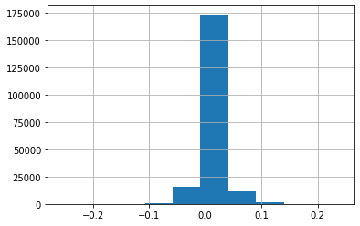

```python
result["score_worsen"].hist()
```

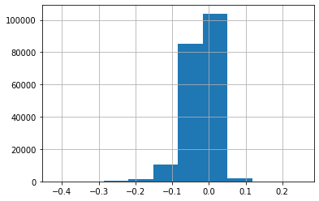

```python
result["score_ensuring"].hist()
```

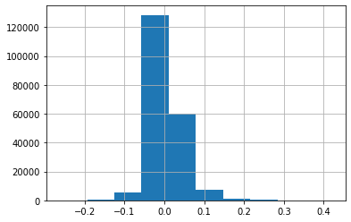

```python
result["score_improve"].hist()
```

```python
result[["score_worsen", "score_ensuring", "score_improve"]].to_csv("result.csv")
result.to_csv("distribution_marginal_effects.csv")
result[["score_worsen", "score_ensuring", "score_improve"]].mean()
```

```
score_worsen      0.006546
score_ensuring   -0.022145
score_improve     0.009653
dtype: float64
```

```python
df = (result[result["_id"].isnull()].assign(rn=result.groupby(['_id_parent'])['score_improve']
                       .rank(method='first', ascending=False))
                      .query('rn <= 200')
                    .sort_values(['_id_parent', 'rn']))
df.head(5)
```

|  | sex | age5B | MIbirthplace | MIcitizen | bula | PAgroe | PAgewiB | IAkv1D | SDaeqeink_k | SDbild4C | ... | orig_p2 | orig_p3 | orig_p4 | orig_p5 | orig_class_score | class_score | score_worsen | score_ensuring | score_improve | rn |
| --- | --- | --- | --- | --- | --- | --- | --- | --- | --- | --- | --- | --- | --- | --- | --- | --- | --- | --- | --- | --- | --- |
| 9 | 2.0 | 4.0 | 10.0 | 10.0 | 1.0 | 167.0 | 52.0 | 2.0 | 6.0 | 5.0 | ... | 0.0 | 0.162409 | 0.802897 | 0.034693 | 0.802897 | 0.802897 | -0.012620 | -0.062391 | 0.075012 | 1.0 |
| 3 | 2.0 | 4.0 | 10.0 | 10.0 | 1.0 | 167.0 | 52.0 | 2.0 | 6.0 | 5.0 | ... | 0.0 | 0.162409 | 0.802897 | 0.034693 | 0.802897 | 0.802897 | -0.029737 | -0.029737 | 0.059474 | 2.0 |
| 1 | 2.0 | 4.0 | 10.0 | 10.0 | 1.0 | 167.0 | 52.0 | 2.0 | 6.0 | 5.0 | ... | 0.0 | 0.162409 | 0.802897 | 0.034693 | 0.802897 | 0.802897 | -0.004690 | -0.023186 | 0.027876 | 3.0 |
| 8 | 2.0 | 4.0 | 10.0 | 10.0 | 1.0 | 167.0 | 52.0 | 2.0 | 6.0 | 5.0 | ... | 0.0 | 0.162409 | 0.802897 | 0.034693 | 0.802897 | 0.802897 | -0.003927 | -0.019415 | 0.023343 | 4.0 |
| 12 | 2.0 | 4.0 | 10.0 | 10.0 | 1.0 | 167.0 | 52.0 | 2.0 | 6.0 | 5.0 | ... | 0.0 | 0.162409 | 0.802897 | 0.034693 | 0.802897 | 0.802897 | 0.004978 | -0.006041 | 0.001063 | 5.0 |

5 rows × 115 columns

```python
_score = 'score_worsen'
g = df[["_changed", _score]].groupby(["_changed"]).agg({_score: ['mean', 'min', 'max', 'std']})
g.columns = ['mean', 'min', 'max', 'std']
g = g.reset_index()
g.sort_values(by="mean", ascending=True, inplace=True)
g = pd.merge(g, df_meta, on='_changed')
g.to_csv("Impact_of_simulating_incremental_change_worsen.csv")
```

```python
def plot(_score, title="", flag_ascending=False):

    # _score = "score_improve"
    g = df[["_changed", _score]].groupby(["_changed"]).agg({_score: ['mean', 'min', 'max', 'std']})
    g.columns = ['mean', 'min', 'max', 'std']
    g = g.reset_index()
    g.sort_values(by="mean", ascending=flag_ascending, inplace=True)
    g = pd.merge(g, df_meta, on='_changed')

    plt.rcdefaults()
    fig, ax = plt.subplots()

    # Example data
    people = g["_changed"]
    y_pos = np.arange(len(people))
    performance = g["mean"]
    error = g["std"]

    ax.barh(y_pos, performance, xerr=error, align='center')
    ax.set_yticks(y_pos)
    ax.set_yticklabels(people)
    ax.invert_yaxis()
    ax.set_xlabel(_score)
    ax.set_title(title)

    plt.show()

    # return g
```

## Analysis

Understanding the distributions of recommendations.

What was the impact of incremental improvfement on the wellbeing score. What is the mean of the rank amongst the suggestions across the entire dataset.

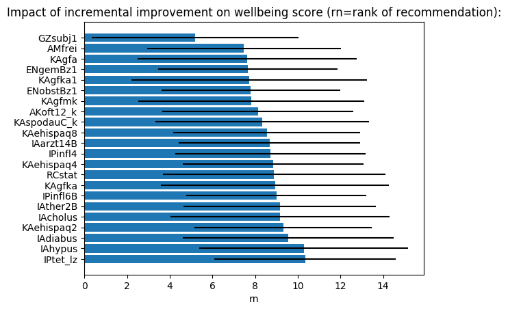

```python
plot("rn", 'Impact of incremental improvement on wellbeing score (rn=rank of recommendation):', True)
```

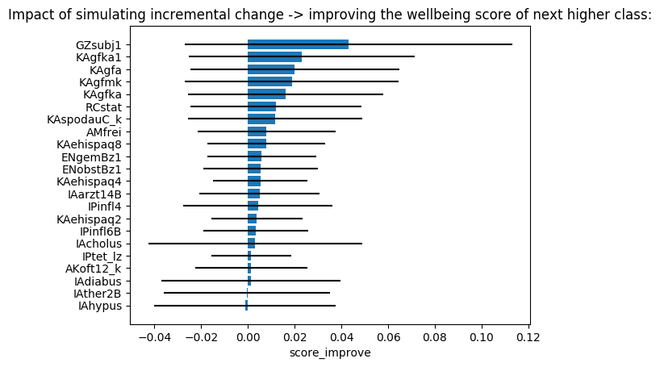

```python
plot("score_improve", 'Impact of simulating incremental change -> improving the wellbeing score of next higher class:')
```

What drivers increased the likelihood of the previous **lower** wellbeing class?

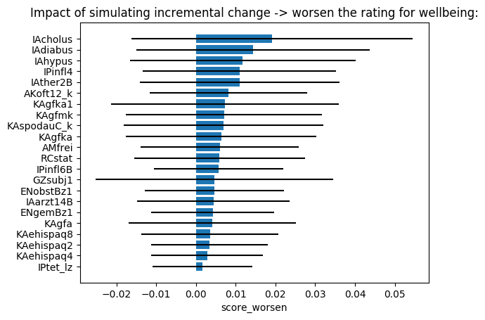

```python
plot("score_worsen", 'Impact of simulating incremental change -> worsen the rating for wellbeing:')
```

## Rank understanding

Across all of the actionable drivers, are there some that are always ranked first? How is the distribution of drivers across the top 5 ranked suggestions?

```python
_score = "rn"
_tmp = df[["_changed", "rn"]]
```

```python
_agg_count = _tmp.groupby(["_changed", "rn"]).agg({_score: ['count']}).reset_index()
_agg_count.columns =["_changed", "rn", 'count']
_agg_count.reset_index(inplace=True)
_chart = _agg_count[_agg_count["rn"] <= 5]
_chart.head(5)
```

|  | index | _changed | rn | count |
| --- | --- | --- | --- | --- |
| 0 | 0 | AKoft12_k | 1.0 | 544 |
| 1 | 1 | AKoft12_k | 2.0 | 875 |
| 2 | 2 | AKoft12_k | 3.0 | 868 |
| 3 | 3 | AKoft12_k | 4.0 | 958 |
| 4 | 4 | AKoft12_k | 5.0 | 889 |

```python
_chart.groupby(["_changed", "rn"]).mean()
_chart.head(5)
```

|  | index | _changed | rn | count |
| --- | --- | --- | --- | --- |
| 0 | 0 | AKoft12_k | 1.0 | 544 |
| 1 | 1 | AKoft12_k | 2.0 | 875 |
| 2 | 2 | AKoft12_k | 3.0 | 868 |
| 3 | 3 | AKoft12_k | 4.0 | 958 |
| 4 | 4 | AKoft12_k | 5.0 | 889 |

```python
_p = _chart.pivot(index="rn", columns="_changed")
_p.to_csv("grouped_barchart_ranking.csv", index=False)

data = []
cols = []

for c in _p.columns:


    if c[1] not in cols:
        data.append(go.Bar(name=c[1], y=_p.index, x=_p["count"][c[1]], orientation='h'))
        cols.append(c[1])

fig = go.Figure(data=data)

fig.update_layout(barmode='group')
fig.show()
```

[interactive chart not shown]